# Project Draft

Luke Fredrickson, Anika Miner, Chris McCabe

4/9/2021

```r
library(tidyverse)
library(ggmap)
library(viridis)

properties <- read.csv("properties.csv")
```

## Number of Properties

Out of the 3086 entries in the rental property data we obtained, 2121 of them are owned by owners who own less than 5 properties. Most of that 2121 is made up of the 1809 properties whose owners only own that one property. So to take a deeper look at some of the major landlords and property management companies in Burlington, we filtered the data to include properties whose owners owned at least 5 properties. Shown in the second graph, you can see that a majority of the owners that own more than four properties own 5-7 properties. The outlier in the data set is Diemer Properties who owns a total of 32 properties.

```r
NumProperties <- properties %>% group_by(Owner) %>% summarize(nProperties = n())

summary(NumProperties$nProperties)
```

```
##    Min. 1st Qu.  Median    Mean 3rd Qu.    Max.
##   1.000   1.000   1.000   1.425   1.000  32.000
```

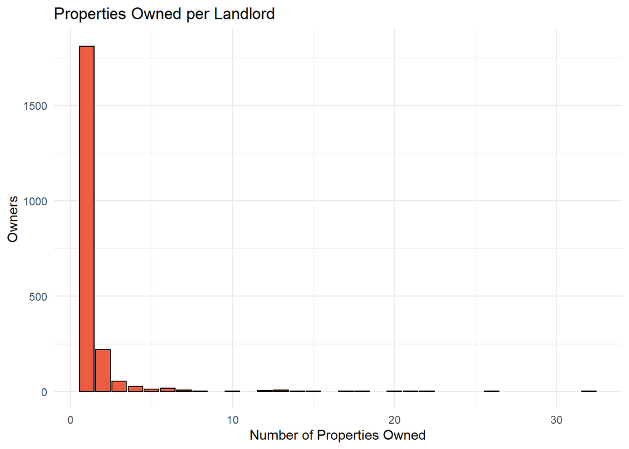

```r
ggplot(data = NumProperties,
       mapping = aes(nProperties)) +
        geom_bar(color = "black",fill="tomato2")+
        labs(title = "Properties Owned per Landlord",x="Number of Properties Owned",
             y = "Owners")+
        theme_minimal()
```

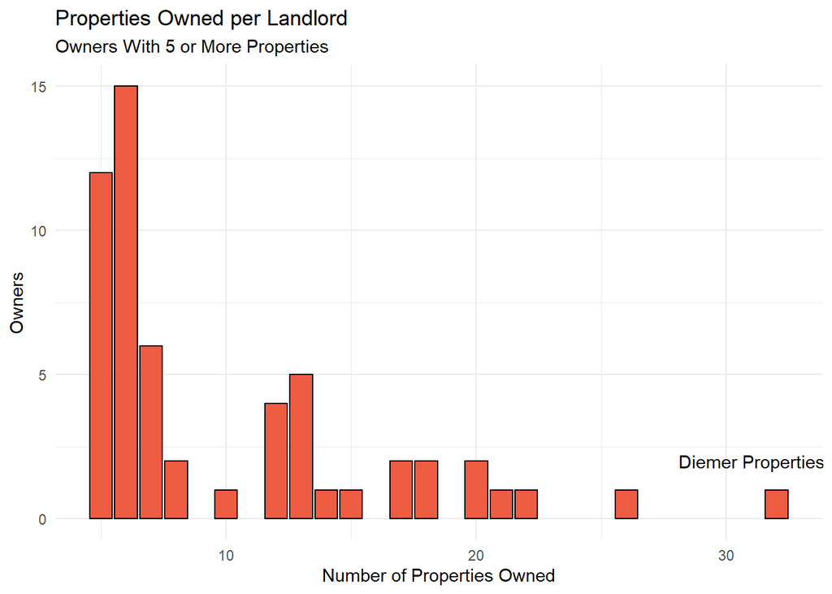

```r
ggplot(data = NumProperties %>% filter(nProperties >= 5),mapping = aes(nProperties)) +
        geom_bar(color = "black",fill="tomato2")+
        labs(title = "Properties Owned per Landlord",x="Number of Properties Owned",
             y = "Owners",subtitle = "Owners With 5 or More Properties")+
         annotate( geom = 'text', x = 31, y = 2, label = "Diemer Properties")+
        theme_minimal()
```

## Types of Rental Properites

There are 15 active land use codes in our dataset for the rental properties in Burlington. The most common is a two family rental, with one to 5 family apartments, and residential condos taking up the very large majority of properties. The commerical/residential properties (residential above commercial properties e.g. Church Street) are the next most common.

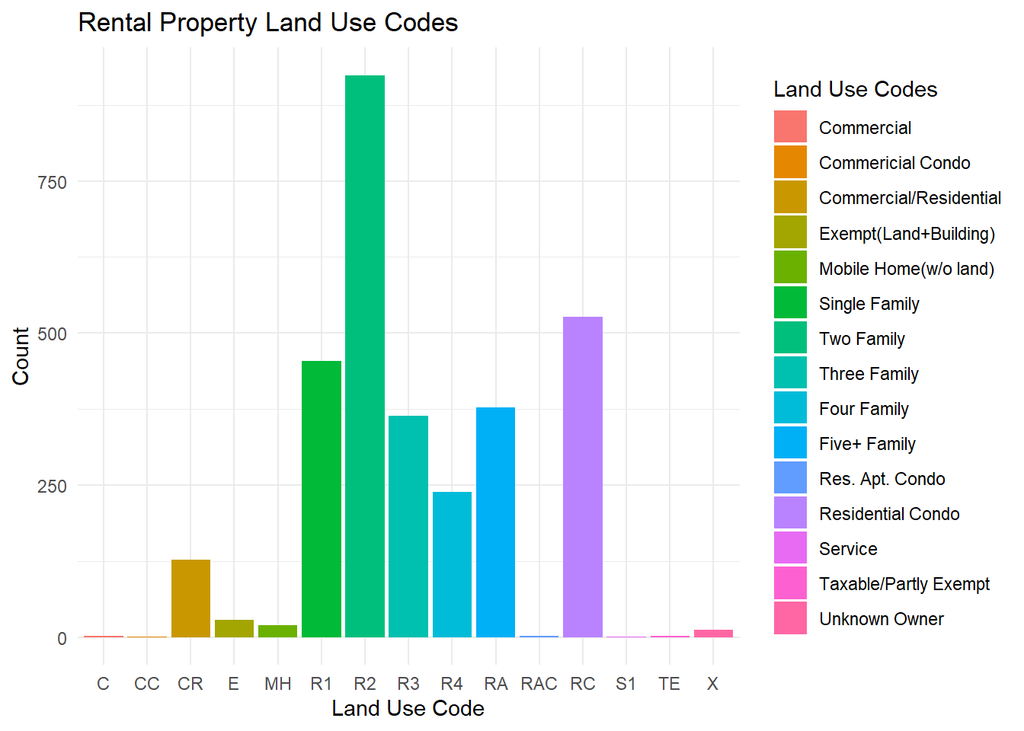

```r
ggplot(data = properties %>% filter(!is.na(LandUseCode)),mapping = aes(x = LandUseCode,fill = LandUseCode)) +
        geom_bar()+
        labs(title = "Rental Property Land Use Codes",
             x = "Land Use Code",
             y = "Count",
             fill = "Land Use Codes")+
        theme_minimal()+
        scale_fill_discrete(labels = c("Commercial","Commericial Condo",
                                       "Commercial/Residential","Exempt(Land+Building)","Mobile Home(w/o land)",
                                       "Single Family","Two Family","Three Family","Four Family","Five+ Family",
                                       "Res. Apt. Condo","Residential Condo","Service","Taxable/Partly Exempt",
                                       "Unknown Owner"))
```

## Certificate of Compliance

The certificate of compliance is based off house inspections and how many years in a row the property has complied with Burlington’s building code. If the property has complied with the code for 5 years, they will have a 5 year Certificate of Compliance. The majority of properties have 4 or 5 year certificates. Properties with a 0 year certificate either failed inspections in the most recent inspection or have not been inspected due to COVID-19.

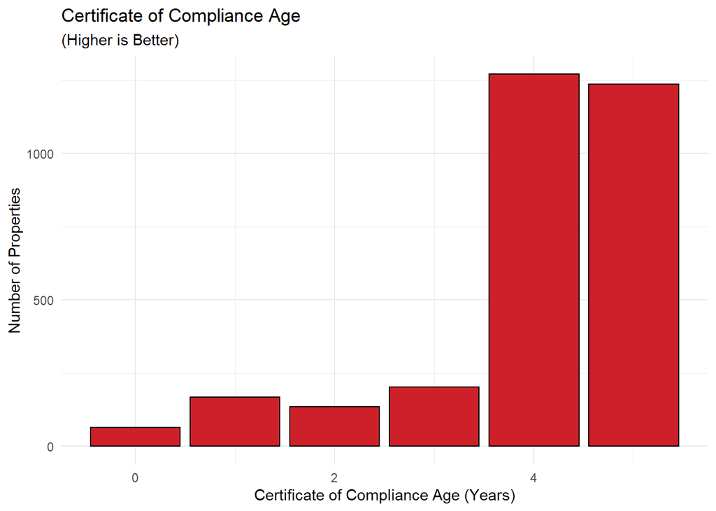

```r
ggplot(data = properties %>% filter(!is.na(CoCYears)), mapping = aes(x=CoCYears)) +
        geom_bar(color = "black",fill = "#CE2029")+
        labs(title = "Certificate of Compliance Age",
             subtitle = "(Higher is Better)",
             x="Certificate of Compliance Age (Years)",
             y = "Number of Properties")+
        theme_minimal()
```

## Does CoC Affect Property Value

The original hypothesis was that the properties with a less desirable CoC would have a lower property value. However, from the boxplots below we learned that the property value across all year values for the CoC was very similar. The median property value for all CoC years was ~$275,000.

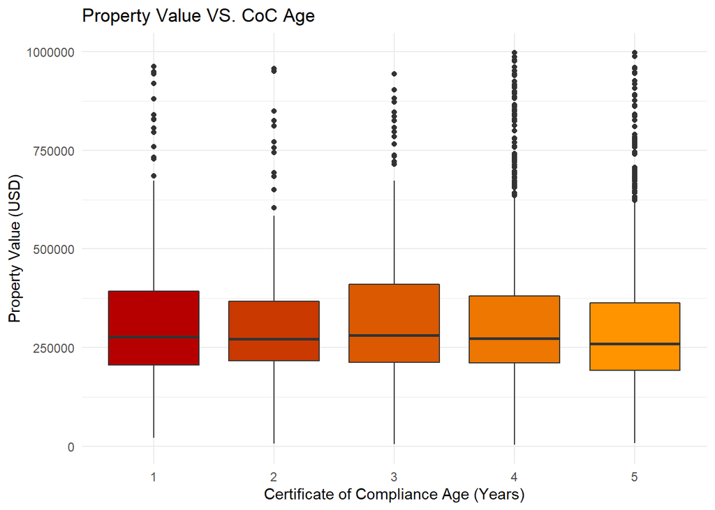

```r
ggplot(data = properties %>%
               filter(!is.na(CoCYears) & CoCYears != 0 & !is.na(LastMhInspectionDate) & PropertyValue < 1000000),
       mapping = aes(x=factor(CoCYears), y=PropertyValue,fill = CoCYears)) +
        geom_boxplot()+
        labs(title = "Property Value VS. CoC Age",
             x = "Certificate of Compliance Age (Years)",
             y = "Property Value (USD)")+
        scale_fill_gradient(high = "#ff9300",low = "#b60000")+
        guides(fill=FALSE)+
        theme_minimal()
```

```r
properties %>%
  group_by(Owner) %>%
  summarize(
    NumberOfProperties = n(),
    TotalValue = sum(PropertyValue)
  ) %>%
  arrange(desc(NumberOfProperties)) %>%
  top_n(20, NumberOfProperties)
```

```
## # A tibble: 21 x 3
##    Owner                                   NumberOfProperties TotalValue
##    <chr>                                                <int>      <dbl>
##  1 DIEMER PROPERTIES                                       32    5695800
##  2 MCGOWAN JOHN STUART                                     26    8411300
##  3 CHAMPLAIN HOUSING TRUST INC                             22    6491200
##  4 BPJS MANAGEMENT LLC                                     21    8839200
##  5 J & S LLC                                               20    9104400
##  6 ROONEY RICHARD A                                        20    3280900
##  7 CLAIRE POINTE OWNERS ASSOCIATION                        18   33130800
##  8 PBGC LLC                                                18    9997500
##  9 BURLINGTON REALTY ASSOCIATES                            17    2463700
## 10 SISTERS & BROTHERS INVESTMENT GROUP LLP                 17   13985100
## # ... with 11 more rows
```